# 3 stress methods at fedecoop sites

Mikaela M. Provost

12/01/2020

```
##       Site Temperature       Date year month expectedT     Dstress
## 1 Bocanita      21.129 2017-10-01 2017    10        NA          NA
## 2 Bocanita      19.612 2017-10-02 2017    10        NA          NA
## 3 Bocanita      19.285 2017-10-03 2017    10        NA          NA
## 4 Bocanita      18.046 2017-10-04 2017    10  18.09485 -0.04885099
## 5 Bocanita      18.788 2017-10-05 2017    10  18.57451  0.21349358
## 6 Bocanita      19.629 2017-10-06 2017    10  19.48824  0.14075676
##   threshold site_mean  site_sd climatology clim_minus_thres
## 1   21.0994  17.52348 3.575921    20.19150       -0.9079045
## 2   21.0994  17.52348 3.575921    20.31131       -0.7880966
## 3   21.0994  17.52348 3.575921    20.42779       -0.6716149
## 4   21.0994  17.52348 3.575921    20.54084       -0.5585607
## 5   21.0994  17.52348 3.575921    20.65037       -0.4490348
## 6   21.0994  17.52348 3.575921    20.75626       -0.3431385
##   degC_above_threshold
## 1                    0
## 2                    0
## 3                    0
## 4                    0
## 5                    0
## 6                    0
```

## Method 1: short-term variability

This method assumes that organisms experience thermal stress when the temperature they experience differs from the temperature they are acclimatized to. Abalone experience more stress when there is a greater difference between experienced and expected temperature on each day. Using a moving window of 4 days, we fit a linear regression using daily temperature and use this to estimate the ‘acclimatized’ temperature for each day. Daily stress is the difference between the acclimatizated and expereinced temperature.

In the time series plots below, color represents temperature abalone experienced above the site-specific thermal threshold (site-specific thermal limits are explained below). Units on the color bars is deg C.

We use these daily stress measures to get a total stress for each site. Total stress per site is the integral of the absolute values. Because there were slight differences in the length of temperature time series among sites, we standardize each integral value by dividing it by the number of days at each site. The units of the standardized integral values are (deg C*day)/day –> deg C (?). These values are plotted in Map 1.

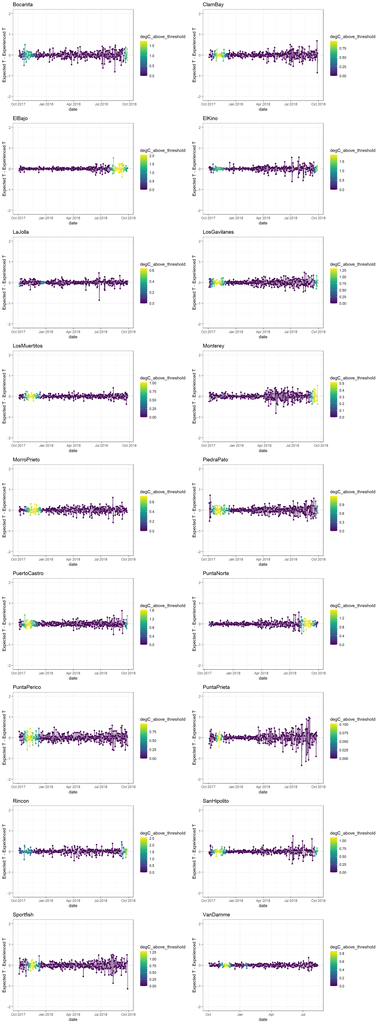

## Method 2: cumulative temperature above thermal limit

Method 2 assumes that stress accumulates when abalone experience temperatures above an upper thermal limit. We assume there is some local adaptation among sites such that extreme temperatures experienced at one site may not be considered extreme, and therefore stressful, at another site. We define site-specific upper thermal limits as one standard deviation above the long-term mean of temperatures observed at that site.

Total stress at each site is the integral of temperatures greater than the site-specific thermal limit (deg C * day). Just as in method 1, we then standaridze the integrals by the number of days per site. Units of standardized integral values are (deg C * day)/day. These values are plotted in Map 2.

## Method 3 (old version): add methods 1 and 2

Method 3 assumes that short-term variability and thermal limits both play a role in explaining an organism’s stress level. Because the units of total stress calculated using methods 1 and 2 are the same, we sum the standardized integrals per each site. These values are plotted in Map 3.

## Method 3 (new version): climatology of potential max - short-term variability

The goal of this method is to combine stress of thermal limits and stress associated with short-terma variability. Short-term variability can be considered ‘good’ if temperatures are high, the variation temperature has a cooling off effect. But there is still some stress associated with rapidly changing temps.

- In this menthod we calculate the potential maximum climatology. I did this using two different methods: a) the climatology of the maximum values over a moving window, and b) climatology of temperatures above the mean climatology.
- Then, we integrate the maximum climatology values that cross the site-specific thermal threshold. And standardize them to the number of days in temperature time series.
- Short-term variability is considered ‘good’ and therefore reducing stress, so we subtract the amount of short-term variability stress as calculated in method 1 from the standardized integrals.

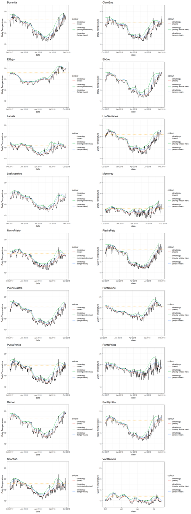

## Maps

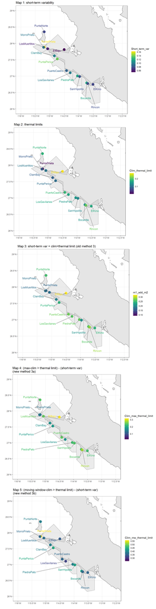

### Comparing stress values

Sites are ordered by increasing latitude.

- Method 1: Short-term variability
- Method 2: Cumulative temp of mean climatology above thermal threshold
- Method 3 (old): Short-term var + cumulative temp above thermal threshold
- Method 3a (new): stress from max climatology above thermal thresold - short-term variability
- Method 3b (new): stress from moving window max climatology above thermal threshold - short-term variability

[figure not shown]